# 02 · Exploratory data analysis

**SkillPath** (IT3051 Fundamentals of Data Mining, group KND_12)

Stage 3, part 2. Every analysis that relates features to the target uses the **training split only** (18,457 of 23,072 respondents). The 4,615 test respondents were set aside right after the deterministic cleaning and are not looked at here, so nothing we learn in EDA can leak into the final evaluation.

Contents

1. Target: job roles and role families (class imbalance)
2. Technology features: support, breadth, role signatures (lift), have vs want
3. Missing values in the technology blocks: true zero vs unknown
4. Experience: distributions, outliers, impossible values, blank = 0
5. Education, region and AI usage by role
6. AI task matrix, AI Exposure Index and perceived AI threat
7. Salary: skew, implausible values, peer-group sizes
8. Leakage screen and redundancy checks
9. Findings that drive preprocessing

```python
import numpy as np
import pandas as pd
import matplotlib.pyplot as plt
import matplotlib as mpl
from scipy.stats import chi2_contingency

from skillpath import config as C
from skillpath import viz
from skillpath.data import load_raw
from skillpath.features import parse_tokens

viz.setup()
pd.set_option("display.max_colwidth", 80)

train = pd.read_parquet(C.PROCESSED_DIR / "train.parquet")
raw = load_raw()
raw_tr = raw.set_index(C.ID_COL).loc[train[C.ID_COL]]  # raw (uncleaned) values of the same people
FAM, JOB = C.TARGET_FAMILY, C.TARGET_JOB
fam_order = train[FAM].value_counts().index.tolist()
print(f"training respondents: {len(train):,}")

DIVERGING = mpl.colors.LinearSegmentedColormap.from_list("bl_rd", [viz.BLUE, "#f0efec", "#e34948"])
```

```
training respondents: 18,457
```

## 1. Target: job roles and role families

**Target decision.** The model predicts the respondent's **specific job role** (`JobRole`, from `DevType`, 20 skill-defined values). Each job role belongs to one of 12 **role families**, and a family's probability is the sum of its job roles' probabilities (`skillpath.targets.family_proba`). One model therefore gives both the top-3 job roles and the top families, as promised in the proposal title and Section 5, and both levels are evaluated.

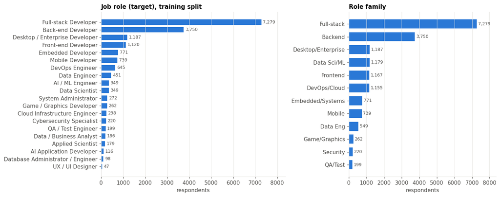

|  | classes | largest | smallest | imbalance ratio | majority share |
| --- | --- | --- | --- | --- | --- |
| JobRole | 20 | 7279 | 47 | 154.9 | 39.4% |
| RoleFamily | 12 | 7279 | 199 | 36.6 | 39.4% |

```python
job_counts = train[JOB].value_counts()
fig, axes = plt.subplots(1, 2, figsize=(13, 5.2), gridspec_kw={"width_ratios": [1.25, 1]})
viz.barh(axes[0], [C.JOB_ROLE_LABEL[j] for j in job_counts.index], job_counts.values)
axes[0].set(title="Job role (target), training split", xlabel="respondents")
fam_counts = train[FAM].value_counts()
viz.barh(axes[1], fam_counts.index.tolist(), fam_counts.values)
axes[1].set(title="Role family", xlabel="respondents")
plt.tight_layout()
viz.save(fig, "02_target_distribution")
plt.show()

imb = pd.DataFrame({
    "classes": [train[JOB].nunique(), train[FAM].nunique()],
    "largest": [job_counts.iloc[0], fam_counts.iloc[0]],
    "smallest": [job_counts.iloc[-1], fam_counts.iloc[-1]],
    "imbalance ratio": [round(job_counts.iloc[0] / job_counts.iloc[-1], 1),
                        round(fam_counts.iloc[0] / fam_counts.iloc[-1], 1)],
    "majority share": [f"{job_counts.iloc[0] / len(train):.1%}", f"{fam_counts.iloc[0] / len(train):.1%}"],
}, index=["JobRole", "RoleFamily"])
imb
```

## 2. Technology features

### 2.1 How often each technology is chosen (support)

```python
rows = []
for block, (have, want, gate) in C.TECH_BLOCKS.items():
    for kind, col in (("have", have), ("want", want)):
        s = train[col].map(parse_tokens).explode().dropna()
        vc = s.value_counts()
        rows.append({"block": block, "list": kind, "options": len(vc),
                     "median support %": round(vc.median() / len(train) * 100, 1),
                     "least chosen": vc.index[-1], "least chosen n": int(vc.iloc[-1]),
                     "options below 0.5%": int((vc < C.MIN_TOKEN_FREQUENCY * len(train)).sum())})
support = pd.DataFrame(rows)
support
```

|  | block | list | options | median support % | least chosen | least chosen n | options below 0.5% |
| --- | --- | --- | --- | --- | --- | --- | --- |
| 0 | Language | have | 42 | 4.6 | Mojo | 38 | 1 |
| 1 | Language | want | 42 | 4.9 | Fortran | 150 | 0 |
| 2 | Database | have | 30 | 3.6 | Datomic | 49 | 1 |
| 3 | Database | want | 30 | 3.4 | Datomic | 122 | 0 |
| 4 | Platform | have | 42 | 9.7 | Yandex Cloud | 73 | 1 |
| 5 | Platform | want | 42 | 6.4 | Yandex Cloud | 85 | 1 |
| 6 | Webframe | have | 28 | 8.3 | Drupal | 298 | 0 |
| 7 | Webframe | want | 28 | 5.0 | Drupal | 144 | 0 |
| 8 | DevEnvs | have | 27 | 7.6 | Trae | 107 | 0 |
| 9 | DevEnvs | want | 27 | 4.9 | Trae | 95 | 0 |
| 10 | AIModels | have | 17 | 6.8 | Reka (Flash 3 or other Reka models) | 10 | 2 |
| 11 | AIModels | want | 17 | 5.3 | Reka (Flash 3 or other Reka models) | 50 | 2 |
| 12 | SOTags | have | 20 | 3.4 | visionOS | 79 | 1 |
| 13 | SOTags | want | 20 | 3.9 | Ultralytics | 98 | 0 |

Almost every technology is picked by enough people to estimate its effect. Only a handful fall below 0.5% of training respondents (about 92 people). **Decision:** technologies below 0.5% support are pooled into a per-block `OTHER` column instead of getting their own column. This keeps rare options from producing unreliable single-feature effects, and the same `OTHER` column absorbs any new technology a web user types that was never seen in training.

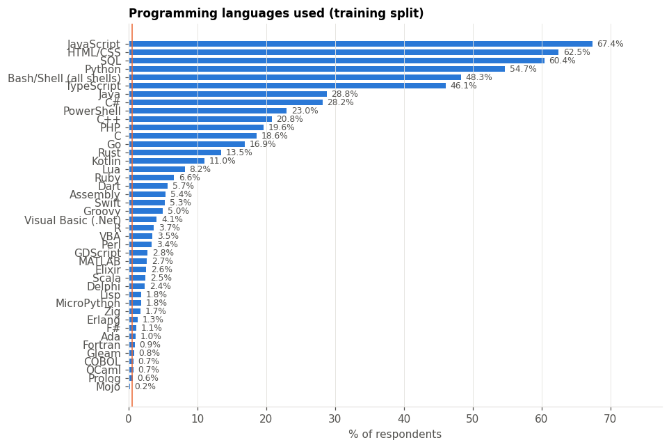

```python
lang = train["LanguageHaveWorkedWith"].map(parse_tokens).explode().value_counts()
fig, ax = plt.subplots(figsize=(9, 6.5))
viz.barh(ax, lang.index.tolist(), (lang / len(train) * 100).round(1).tolist(), fmt="{:.1f}%")
ax.axvline(C.MIN_TOKEN_FREQUENCY * 100, color=viz.ORANGE, lw=1)
ax.set(title="Programming languages used (training split)", xlabel="% of respondents")
viz.save(fig, "02_language_support")
plt.show()
```

### 2.2 Breadth: how many technologies people tick

```python
breadth = pd.DataFrame({
    block: train[have].map(parse_tokens).map(len) for block, (have, _, _) in C.TECH_BLOCKS.items()
})
desc = breadth.describe(percentiles=[0.5, 0.9, 0.99]).T[["mean", "50%", "90%", "99%", "max"]].round(1)
desc["skew"] = breadth.skew().round(2)
desc
```

|  | mean | 50% | 90% | 99% | max | skew |
| --- | --- | --- | --- | --- | --- | --- |
| Language | 6.0 | 6.0 | 10.0 | 15.0 | 37.0 | 1.35 |
| Database | 2.8 | 2.0 | 6.0 | 10.0 | 26.0 | 1.19 |
| Platform | 5.5 | 5.0 | 12.0 | 19.0 | 36.0 | 0.81 |
| Webframe | 2.8 | 2.0 | 6.0 | 11.0 | 23.0 | 1.22 |
| DevEnvs | 2.9 | 3.0 | 6.0 | 10.0 | 23.0 | 1.15 |
| AIModels | 1.7 | 1.0 | 5.0 | 10.0 | 15.0 | 1.68 |
| SOTags | 1.2 | 1.0 | 3.0 | 7.0 | 14.0 | 1.86 |

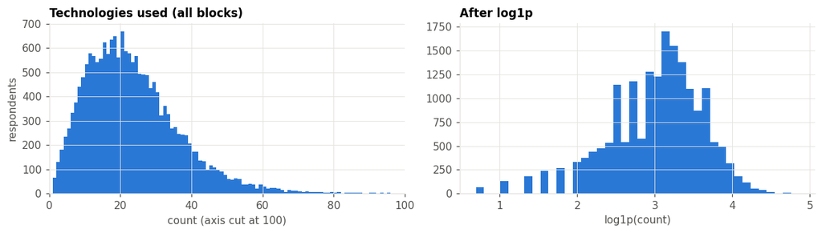

```
skew before: 1.13   after log1p: -0.69
max technologies ticked by one person: 128  (people above 100: 7)
```

```python
fig, axes = plt.subplots(1, 2, figsize=(11, 3.2))
tot = breadth.sum(axis=1)
axes[0].hist(tot, bins=range(0, tot.max() + 2), color=viz.BLUE)
axes[0].set(title="Technologies used (all blocks)", xlabel="count (axis cut at 100)", ylabel="respondents",
            xlim=(0, 100))
axes[1].hist(np.log1p(tot), bins=40, color=viz.BLUE)
axes[1].set(title="After log1p", xlabel="log1p(count)")
for a in axes:
    a.grid(axis="y")
plt.tight_layout()
viz.save(fig, "02_breadth")
plt.show()
print(f"skew before: {tot.skew():.2f}   after log1p: {np.log1p(tot).skew():.2f}")
print(f"max technologies ticked by one person: {tot.max()}  (people above 100: {(tot > 100).sum()})")
```

Counts are right-skewed with a long tail (after removing straight-liners, a few people still tick more than 100 options across all lists). The log transform limits their influence without deleting them. The breadth features are therefore **log1p-transformed**, which also puts them on a scale close to the 0/1 technology columns.

### 2.3 Role signatures: which technologies are characteristic of each family (lift)

Lift = P(technology | family) / P(technology). Lift 2 means the technology is twice as common in that family as overall. This is the association analysis that later powers the "skills that match" and "skill gap" explanations, and it shows the features carry real signal for the target.

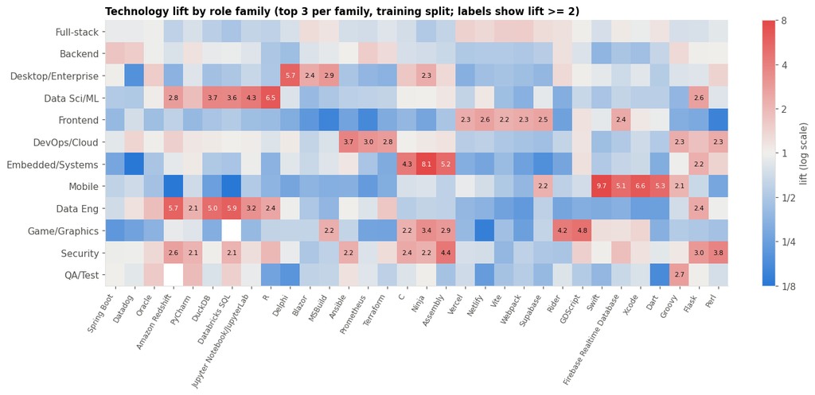

```python
H = pd.concat([
    train[have].map(parse_tokens).explode().pipe(lambda s: pd.crosstab(s.index, s)).add_prefix(f"{b}: ")
    for b, (have, _, _) in C.TECH_BLOCKS.items() if b in ("Language", "Database", "Platform", "Webframe", "DevEnvs")
], axis=1).reindex(train.index, fill_value=0).clip(upper=1)
p_tech = H.mean()
p_tech_fam = H.groupby(train[FAM]).mean()
lift = p_tech_fam / p_tech
eligible = p_tech_fam >= 0.10  # used by at least 10% of the family
top = set()
for f in lift.index:
    top |= set(lift.loc[f][eligible.loc[f]].sort_values(ascending=False).head(3).index)
top = sorted(top, key=lambda t: lift[t].idxmax())
L = np.log2(lift.loc[fam_order, top])
fig, ax = plt.subplots(figsize=(13, 5.2))
im = ax.imshow(L.values, cmap=DIVERGING, vmin=-3, vmax=3, aspect="auto")
ax.set_xticks(range(len(top)), [t.split(": ")[1] for t in top], rotation=60, ha="right", fontsize=8)
ax.set_yticks(range(len(fam_order)), fam_order)
ax.grid(False)
for i in range(L.shape[0]):
    for j in range(L.shape[1]):
        v = lift.loc[fam_order[i], top[j]]
        if v >= 2:
            ax.text(j, i, f"{v:.1f}", ha="center", va="center", fontsize=7, color="white" if v > 5 else viz.TEXT)
cb = fig.colorbar(im, ax=ax, fraction=0.02)
cb.set_ticks([-3, -2, -1, 0, 1, 2, 3], labels=["1/8", "1/4", "1/2", "1", "2", "4", "8"])
cb.set_label("lift (log scale)")
ax.set_title("Technology lift by role family (top 3 per family, training split; labels show lift >= 2)")
viz.save(fig, "02_lift_heatmap")
plt.show()
```

```python
sig = {}
for f in fam_order:
    s = lift.loc[f][eligible.loc[f]].sort_values(ascending=False).head(5)
    sig[f] = ", ".join(f"{t.split(': ')[1]} ({v:.1f})" for t, v in s.items())
pd.Series(sig, name="top-5 technologies by lift (lift)").to_frame()
```

|  | top-5 technologies by lift (lift) |
| --- | --- |
| Full-stack | Webpack (1.5), Vite (1.5), Vercel (1.4), PHP (1.4), TypeScript (1.4) |
| Backend | Spring Boot (1.7), Prometheus (1.5), Datadog (1.5), Kubernetes (1.5), Intell... |
| Desktop/Enterprise | Delphi (5.7), MSBuild (2.9), Blazor (2.4), Ninja (2.3), C++ (2.1) |
| Data Sci/ML | R (6.5), Jupyter Notebook/JupyterLab (4.3), DuckDB (3.7), Databricks SQL (3.... |
| Frontend | Netlify (2.6), Supabase (2.5), Firebase Realtime Database (2.4), Webpack (2.... |
| DevOps/Cloud | Ansible (3.7), Prometheus (3.0), Terraform (2.8), Podman (2.5), Go (2.3) |
| Embedded/Systems | Ninja (8.1), Assembly (5.2), C (4.3), MATLAB (4.1), C++ (3.5) |
| Mobile | Swift (9.7), Xcode (6.6), Dart (5.3), Kotlin (5.2), Firebase Realtime Databa... |
| Data Eng | Databricks SQL (5.9), Amazon Redshift (5.7), DuckDB (5.0), Snowflake (5.0), ... |
| Game/Graphics | GDScript (4.8), Rider (4.2), Ninja (3.4), C++ (3.2), Assembly (2.9) |
| Security | Assembly (4.4), Perl (3.8), Flask (3.0), Splunk (2.9), Django (2.7) |
| QA/Test | Groovy (2.7), PyCharm (1.9), Oracle (1.6), Microsoft SQL Server (1.5), Choco... |

Most families have a clear technology signature: Swift, Xcode and Kotlin for Mobile (lift 5 to 10), R and Jupyter for Data Sci/ML, Ansible, Prometheus and Terraform for DevOps/Cloud, Assembly and C for Embedded, Databricks and Snowflake for Data Eng, GDScript and C++ for Game/Graphics. Full-stack, Backend and QA/Test have the weakest signatures (top lift below 3) because they use the most common technologies, which predicts they will be the hardest classes to separate.

### 2.4 Job roles inside the same family

Four families contain more than one job role. Predicting the specific role only makes sense if roles in the same family use different technologies. Within-family lift = P(technology | job role) / P(technology | family): it shows what separates, for example, a Data Scientist from an AI/ML Engineer.

```python
H_job = H.groupby(train[JOB]).mean()
multi_fams = [f for f in fam_order if sum(v == f for v in C.ROLE_FAMILY.values()) > 1]
rows = []
for f in multi_fams:
    p_f = p_tech_fam.loc[f]
    for job in [j for j, g in C.ROLE_FAMILY.items() if g == f]:
        p_j = H_job.loc[job]
        within = (p_j / p_f.replace(0, np.nan))[(p_j >= 0.10)].sort_values(ascending=False).head(4)
        rows.append({"family": f, "job role": C.JOB_ROLE_LABEL[job], "n (train)": int((train[JOB] == job).sum()),
                     "most distinctive within the family (within-family lift)":
                         ", ".join(f"{t.split(': ')[1]} ({v:.1f})" for t, v in within.items())})
pd.DataFrame(rows)
```

|  | family | job role | n (train) | most distinctive within the family (within-family lift) |
| --- | --- | --- | --- | --- |
| 0 | Data Sci/ML | Data Scientist | 349 | R (1.7), Databricks SQL (1.4), Snowflake (1.4), DuckDB (1.4) |
| 1 | Data Sci/ML | AI / ML Engineer | 349 | Redis (1.6), Terraform (1.6), Cursor (1.5), TypeScript (1.5) |
| 2 | Data Sci/ML | Applied Scientist | 179 | Fortran (3.4), MATLAB (2.5), Assembly (2.1), C (1.9) |
| 3 | Data Sci/ML | AI Application Developer | 116 | Firebase Realtime Database (3.8), Cloud Firestore (3.2), Firebase (3.1), pnp... |
| 4 | Data Sci/ML | Data / Business Analyst | 186 | ASP.NET (2.7), VBA (2.6), ASP.NET Core (2.4), Microsoft Access (2.2) |
| 5 | Frontend | Front-end Developer | 1120 | Express (1.0), TypeScript (1.0), Elasticsearch (1.0), Kubernetes (1.0) |
| 6 | Frontend | UX / UI Designer | 47 | MicroPython (12.4), Pocketbase (8.2), Amazon Redshift (8.2), Cline and/or Ro... |
| 7 | DevOps/Cloud | DevOps Engineer | 645 | Groovy (1.4), Spring Boot (1.3), Gradle (1.3), MSBuild (1.3) |
| 8 | DevOps/Cloud | Cloud Infrastructure Engineer | 238 | BigQuery (1.7), Ruby on Rails (1.7), Dynamodb (1.7), Valkey (1.7) |
| 9 | DevOps/Cloud | System Administrator | 272 | Microsoft Access (3.0), VBA (2.9), WordPress (1.9), Composer (1.7) |
| 10 | Data Eng | Data Engineer | 451 | Scala (1.2), R (1.2), Databricks SQL (1.2), BigQuery (1.2) |
| 11 | Data Eng | Database Administrator / Engineer | 98 | MSBuild (2.9), Visual Basic (.Net) (2.8), Drupal (2.7), WordPress (2.6) |

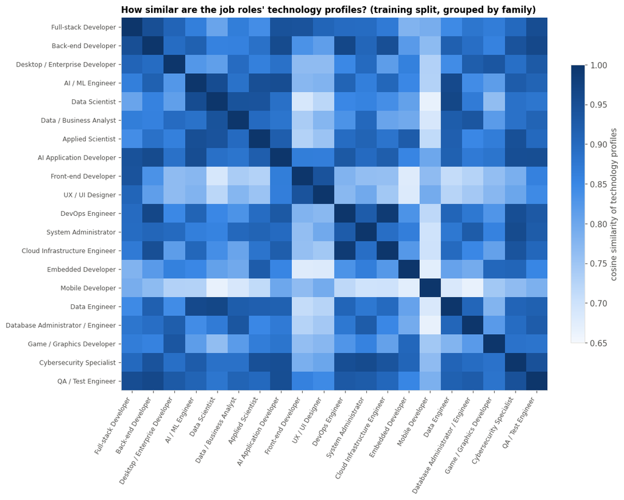

```
most similar job-role pairs:
JobRole                        JobRole
Cloud Infrastructure Engineer  DevOps Engineer         0.988
Data Engineer                  Data Scientist          0.966
DevOps Engineer                Back-end Developer      0.964
QA / Test Engineer             Back-end Developer      0.962
AI / ML Engineer               Data Engineer           0.959
AI Application Developer       Back-end Developer      0.957
Cybersecurity Specialist       System Administrator    0.957
AI / ML Engineer               Data Scientist          0.954

least similar pairs:
JobRole                            JobRole
Embedded Developer                 Front-end Developer    0.677
                                   Mobile Developer       0.672
Data Scientist                     Mobile Developer       0.665
Database Administrator / Engineer  Mobile Developer       0.665
```

```python
# Similarity of the 20 job-role technology profiles (cosine of prevalence vectors)
# order roles by family so sibling roles sit next to each other
job_order = sorted(job_counts.index, key=lambda j: (fam_order.index(C.ROLE_FAMILY[j]), -job_counts[j]))
prof = H_job.loc[job_order]
unit = prof.div(np.sqrt((prof ** 2).sum(axis=1)), axis=0)
sim = unit @ unit.T
labels = [C.JOB_ROLE_LABEL[j] for j in sim.index]
fig, ax = plt.subplots(figsize=(10.5, 8.5))
im = ax.imshow(sim.values, cmap=viz.seq_cmap(), vmin=0.65, vmax=1, aspect="auto")
ax.set_xticks(range(len(labels)), labels, rotation=60, ha="right", fontsize=8)
ax.set_yticks(range(len(labels)), labels, fontsize=8)
ax.grid(False)
fig.colorbar(im, ax=ax, fraction=0.03, label="cosine similarity of technology profiles")
ax.set_title("How similar are the job roles' technology profiles? (training split, grouped by family)")
viz.save(fig, "02_jobrole_similarity")
plt.show()

s_ = sim.where(~np.eye(len(sim), dtype=bool)).stack()
pairs_ = s_[[a < b for a, b in s_.index]].sort_values(ascending=False)
print("most similar job-role pairs:")
print(pairs_.head(8).rename(index=C.JOB_ROLE_LABEL).round(3).to_string())
print("\nleast similar pairs:")
print(pairs_.tail(4).rename(index=C.JOB_ROLE_LABEL).round(3).to_string())
```

- Roles inside a family do differ. In Data Sci/ML, Data Scientists lean on R and Databricks, AI/ML Engineers on Terraform, Redis and Cursor, Applied Scientists on Fortran and MATLAB, AI Application Developers on Firebase, and Data / Business Analysts on VBA and Microsoft Access. System Administrators (Access, VBA, WordPress) differ from Cloud Infrastructure Engineers (BigQuery, DynamoDB).
- Front-end Developer shows lift of about 1 because it makes up almost the whole Frontend family. The UX / UI Designer lifts are based on only 47 people, so values such as MicroPython 12.4 are small-sample noise, not a real signature.
- Some roles are very close: Cloud Infrastructure Engineer vs DevOps Engineer (0.99), Data Engineer vs Data Scientist (0.97), DevOps vs Back-end (0.96). The least similar are Embedded vs Front-end or Mobile (about 0.67). The model will often confuse the close pairs. This is expected and is exactly why SkillPath shows the **top 3** job roles with probabilities and also the family total, instead of one hard answer.
- Predicting job roles and summing to families loses little compared with a family-only target, while giving users the specific role names they asked for. Both levels will be compared in Stage 6-7.

### 2.5 "Have" versus "want" lists

Is the want list just a copy of the have list? If so it would be redundant.

```python
phis = []
for b, (have, want, _) in C.TECH_BLOCKS.items():
    hv = train[have].map(parse_tokens)
    wv = train[want].map(parse_tokens)
    for t in sorted(set().union(*hv) & set().union(*wv)):
        h = hv.map(lambda s: t in s).astype(int)
        w = wv.map(lambda s: t in s).astype(int)
        if h.sum() >= 50 and w.sum() >= 50:
            phis.append({"block": b, "technology": t, "phi": np.corrcoef(h, w)[0, 1]})
phis = pd.DataFrame(phis)
print(phis["phi"].describe().round(3).to_string())
print(f"\npairs with phi > 0.8: {(phis.phi > 0.8).sum()}  (max {phis.phi.max():.2f})")

new_want = pd.Series(dtype=float)
for b, (have, want, _) in C.TECH_BLOCKS.items():
    diff = [w - h for h, w in zip(train[have].map(parse_tokens), train[want].map(parse_tokens))]
    new_want = pd.concat([new_want, pd.Series([t for s in diff for t in s]).value_counts()])
print("\nmost wanted technologies that people do NOT use yet:")
print((new_want.sort_values(ascending=False).head(10) / len(train) * 100).round(1).astype(str).add("%").to_string())
```

```
count    203.000
mean       0.506
std        0.120
min        0.182
25%        0.435
50%        0.501
75%        0.583
max        0.764

pairs with phi > 0.8: 0  (max 0.76)
```

```
most wanted technologies that people do NOT use yet:
Rust          18.5%
Go            14.4%
Kubernetes     8.6%
PostgreSQL     7.5%
Python         6.8%
Redis          6.6%
TypeScript     6.4%
Kotlin         6.3%
Zig            6.0%
C++            5.1%
```

Have and want are related (median phi about 0.5) but never close to duplicates (all below 0.8), so both lists are kept. The want list adds a different signal: what people are moving towards (for example Rust, Go and Kubernetes are wanted by many who do not use them yet). An engineered feature, `want_new_count` (number of wanted technologies not already used), captures this learning direction.

## 3. Missing values in the technology blocks

This repeats the key finding from notebook 01, now on the training cohort: most empty technology lists are **true zeros** (the respondent answered "No" to the gate question), and only a minority are unknown.

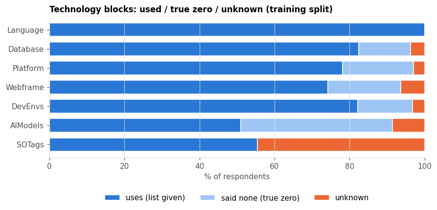

| block | uses (list given) | said none (true zero) | unknown |
| --- | --- | --- | --- |
| Language | 100.0 | 0.0 | 0.0 |
| Database | 82.5 | 13.8 | 3.7 |
| Platform | 78.1 | 19.0 | 2.9 |
| Webframe | 74.2 | 19.4 | 6.4 |
| DevEnvs | 82.2 | 14.5 | 3.3 |
| AIModels | 50.9 | 40.5 | 8.5 |
| SOTags | 55.4 | 0.0 | 44.6 |

```python
rows = []
for b, (have, want, gate) in C.TECH_BLOCKS.items():
    used = train[have].notna()
    said_no = (train[gate] == "No") if gate else pd.Series(False, index=train.index)
    rows.append({"block": b, "uses (list given)": used.mean(), "said none (true zero)": (~used & said_no).mean(),
                 "unknown": (~used & ~said_no).mean()})
state = pd.DataFrame(rows).set_index("block")
fig, ax = plt.subplots(figsize=(9, 3.4))
left = np.zeros(len(state))
for col, colr in zip(state.columns, [viz.BLUE, "#9ec5f4", viz.ORANGE]):
    ax.barh(state.index, state[col] * 100, left=left, color=colr, label=col, height=0.7,
            edgecolor="white", linewidth=1)
    left += state[col].values * 100
ax.invert_yaxis()
ax.set(title="Technology blocks: used / true zero / unknown (training split)", xlabel="% of respondents")
ax.legend(ncol=3, loc="lower center", bbox_to_anchor=(0.5, -0.36))
ax.grid(axis="y", visible=False)
viz.save(fig, "02_block_state")
plt.show()
(state * 100).round(1)
```

**Decision (missing values, technology):** encode every block with 0/1 columns and add a `<block>_unknown` indicator that is 1 only when the list is empty *and* the person did not say "No". A "No" stays all zeros with unknown = 0. We do **not** impute technologies (we cannot guess what someone uses), and we do **not** drop these rows (that would remove 10-45% of the cohort and bias it towards people who finished the survey). SOTags has no gate question, so an empty SOTags list is always unknown. The web form mirrors this with an explicit "I don't use any" option.

## 4. Experience

```python
exp_raw = raw_tr[["YearsCode", "WorkExp", "Age"]].copy()
print("raw values, training split:")
print(exp_raw[["YearsCode", "WorkExp"]].describe(percentiles=[0.25, 0.5, 0.75, 0.99]).round(1).T.to_string())
print("\nskew:", exp_raw[["YearsCode", "WorkExp"]].skew().round(2).to_dict())
```

```
raw values, training split:
             count  mean   std  min  25%   50%   75%   99%    max
YearsCode  18302.0  17.0  10.9  1.0  9.0  15.0  24.0  46.0  100.0
WorkExp    17944.0  12.9  10.0  1.0  5.0  10.0  19.0  42.0  100.0

skew: {'YearsCode': 1.02, 'WorkExp': 1.14}
```

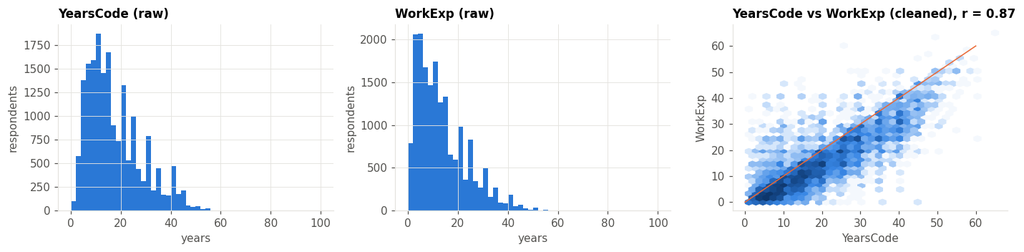

```python
fig, axes = plt.subplots(1, 3, figsize=(13, 3.3))
for ax, col in zip(axes[:2], ["YearsCode", "WorkExp"]):
    ax.hist(exp_raw[col].dropna(), bins=range(0, 102, 2), color=viz.BLUE)
    ax.set(title=f"{col} (raw)", xlabel="years", ylabel="respondents")
    ax.grid(axis="y")
ax = axes[2]
hb = ax.hexbin(train["YearsCode"], train["WorkExp"], gridsize=35, cmap=viz.seq_cmap(), mincnt=1, bins="log")
ax.plot([0, 60], [0, 60], color=viz.ORANGE, lw=1)
r = train[["YearsCode", "WorkExp"]].corr().iloc[0, 1]
ax.set(title=f"YearsCode vs WorkExp (cleaned), r = {r:.2f}", xlabel="YearsCode", ylabel="WorkExp")
ax.grid(False)
plt.tight_layout()
viz.save(fig, "02_experience")
plt.show()
```

### 4.1 Outliers and impossible values

Both variables are right-skewed with a tail up to 100 years. A standard IQR rule would flag every senior developer (30+ years) as an outlier, which is wrong: long careers are real. Instead we check **plausibility against the age band**: coding cannot start before about age 5 and paid work before about 14.

```python
upper = exp_raw["Age"].map(C.AGE_BAND_UPPER)
bad_code = exp_raw["YearsCode"] > (upper - C.MIN_START_AGE_CODING).fillna(C.MAX_YEARS_FALLBACK)
bad_work = exp_raw["WorkExp"] > (upper - C.MIN_START_AGE_WORK).fillna(C.MAX_YEARS_FALLBACK)
q1, q3 = exp_raw["YearsCode"].quantile([0.25, 0.75])
iqr_flag = exp_raw["YearsCode"] > q3 + 1.5 * (q3 - q1)
print(f"IQR rule would flag YearsCode > {q3 + 1.5 * (q3 - q1):.0f} years: {iqr_flag.sum():,} respondents")
print(f"impossible for age band: YearsCode {bad_code.sum()}, WorkExp {bad_work.sum()}")
print("\nexamples of impossible values:")
print(exp_raw[bad_code | bad_work].value_counts().head(8).to_string())
```

```
IQR rule would flag YearsCode > 46 years: 173 respondents
impossible for age band: YearsCode 13, WorkExp 15

examples of impossible values:
YearsCode  WorkExp  Age
5.0        50.0     18-24 years old    2
40.0       15.0     35-44 years old    1
3.0        44.0     18-24 years old    1
20.0       1.0      18-24 years old    1
40.0       23.0     35-44 years old    1
11.0       11.0     18-24 years old    1
25.0       25.0     25-34 years old    1
40.0       24.0     35-44 years old    1
```

**Decision (outliers, experience):** keep long careers; set only the values that are impossible for the respondent's age band to missing (they are then imputed with the training median), and apply a log1p transform to reduce the skew. Age is used for this check only, it is not a model input.

`WorkExp > YearsCode` is **not** an error: `WorkExp` is total professional work, which includes years in another field before learning to code. These career changers become an engineered flag, `CareerChanger`.

```python
changer = (train["WorkExp"] > train["YearsCode"])
print(f"career changers in training split: {changer.sum():,} ({changer.mean():.1%})")
print(pd.crosstab(train[FAM], changer, normalize="index")[True].sort_values(ascending=False).round(3)
      .rename("share of career changers").to_string())
```

```
career changers in training split: 1,158 (6.3%)
RoleFamily
QA/Test               0.236
DevOps/Cloud          0.154
Security              0.145
Data Eng              0.135
Data Sci/ML           0.133
Frontend              0.069
Desktop/Enterprise    0.054
Mobile                0.046
Embedded/Systems      0.044
Full-stack            0.044
Backend               0.034
Game/Graphics         0.031
```

### 4.2 Blank WorkExp means zero years

The question says: *"If your answer is '0', please leave blank."* No respondent entered 0 (the minimum is 1). The people who left it blank look like new entrants:

```python
blank = exp_raw["WorkExp"].isna() & exp_raw["YearsCode"].notna()
cmp = pd.DataFrame({
    "blank WorkExp": [blank.sum(), exp_raw.loc[blank, "YearsCode"].median(),
                      (exp_raw.loc[blank, "Age"] == "18-24 years old").mean()],
    "WorkExp given": [(~blank).sum(), exp_raw.loc[~blank, "YearsCode"].median(),
                      (exp_raw.loc[~blank, "Age"] == "18-24 years old").mean()],
}, index=["respondents", "median YearsCode", "share aged 18-24"])
cmp.round(2)
```

|  | blank WorkExp | WorkExp given |
| --- | --- | --- |
| respondents | 437.00 | 18020.00 |
| median YearsCode | 5.00 | 15.00 |
| share aged 18-24 | 0.71 | 0.12 |

**Decision (missing values, experience):** a blank `WorkExp` with an answered `YearsCode` is set to **0**, following the survey instruction. Imputing the median (10 years) would turn students into mid-career professionals. Remaining gaps (both fields blank, or impossible values) are imputed with the training median plus a missing-indicator column.

## 5. Education, region and AI usage by role family

Cramér's V measures association between two categorical variables (0 = none, 1 = perfect). Values shown for the training split.

```python
def cramers_v(x, y):
    t = pd.crosstab(x, y)
    chi2 = chi2_contingency(t, correction=False)[0]
    return float(np.sqrt(chi2 / (t.values.sum() * (min(t.shape) - 1))))

cats = ["EdLevel", "Region", "LearnCodeAI", "AISelect", "AIAgents", "AIAcc", "AISent",
        "OrgSize", "Industry", "RemoteWork", "ICorPM", "Age", "MainBranch"]
assoc = pd.Series({c: cramers_v(train[c].fillna("Missing"), train[FAM]) for c in cats}).sort_values(ascending=False)
assoc.round(3).rename("Cramér's V with RoleFamily").to_frame()
```

|  | Cramér's V with RoleFamily |
| --- | --- |
| MainBranch | 0.219 |
| Industry | 0.108 |
| EdLevel | 0.096 |
| AISelect | 0.087 |
| RemoteWork | 0.082 |
| OrgSize | 0.077 |
| Age | 0.075 |
| LearnCodeAI | 0.072 |
| ICorPM | 0.071 |
| AIAcc | 0.071 |
| AIAgents | 0.067 |
| AISent | 0.065 |
| Region | 0.065 |

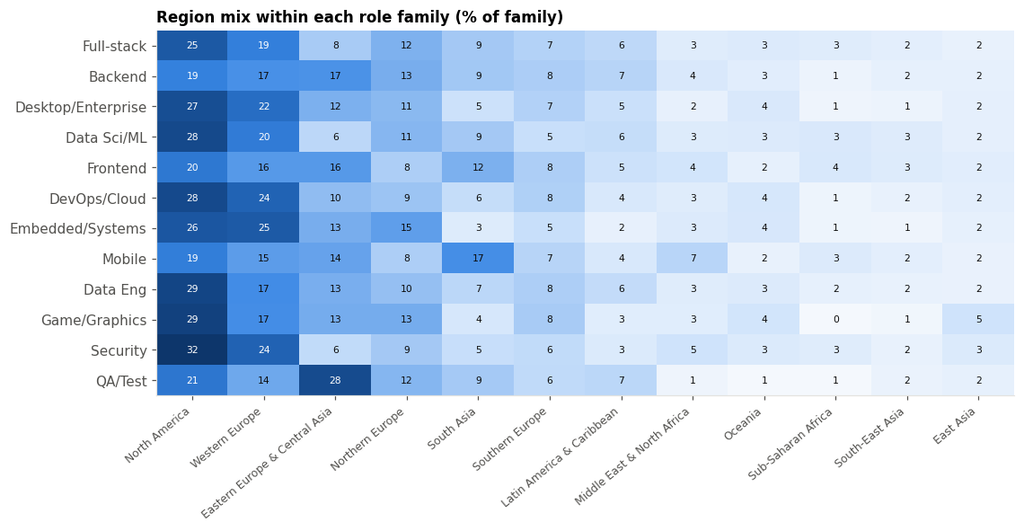

```python
def share_heatmap(col, order, title, fname):
    tab = pd.crosstab(train[FAM], train[col], normalize="index").reindex(index=fam_order, columns=order) * 100
    fig, ax = plt.subplots(figsize=(1.0 + 0.85 * len(order), 4.8))
    im = ax.imshow(tab.values, cmap=viz.seq_cmap(), aspect="auto")
    ax.set_xticks(range(len(order)), [o[:34] for o in order], rotation=40, ha="right", fontsize=8)
    ax.set_yticks(range(len(fam_order)), fam_order)
    ax.grid(False)
    for i in range(tab.shape[0]):
        for j in range(tab.shape[1]):
            v = tab.values[i, j]
            ax.text(j, i, f"{v:.0f}", ha="center", va="center", fontsize=7,
                    color="white" if v > tab.values.max() * 0.6 else viz.TEXT)
    ax.set_title(title)
    viz.save(fig, fname)
    plt.show()

regions = train["Region"].value_counts().index.tolist()
share_heatmap("Region", regions, "Region mix within each role family (% of family)", "02_region_by_family")
```

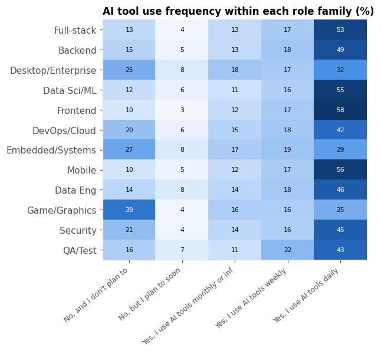

```python
ai_order = sorted(C.ORDINAL_MAPS["AISelect"], key=C.ORDINAL_MAPS["AISelect"].get)
share_heatmap("AISelect", ai_order, "AI tool use frequency within each role family (%)", "02_aiselect_by_family")
```

## 6. AI task matrix, AI Exposure Index and AI threat

For 13 development tasks, respondents said whether they do it mostly/partially with AI now, plan to, or do not plan to. Each task appears in exactly one of the five level columns per person (verified: 0 conflicts), so the matrix can be turned into one level per task.

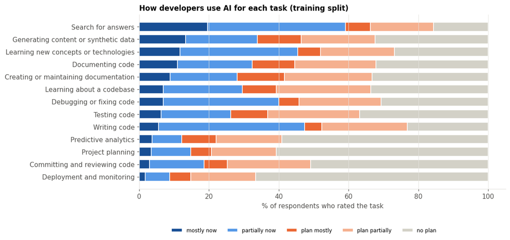

```python
ai = pd.read_parquet(C.REFERENCE_DIR / "ai_exposure_role_cohort.parquet")
ai = ai[ai["split"] == "train"]
task_cols = [c for c in ai.columns if c.startswith("task: ")]
levels = ["mostly_now", "partially_now", "plan_mostly", "plan_partially", "no_plan"]
dist = pd.DataFrame({t.replace("task: ", ""): ai[t].value_counts(normalize=True) for t in task_cols}).T[levels] * 100
dist = dist.sort_values(["mostly_now", "partially_now"], ascending=False)
fig, ax = plt.subplots(figsize=(10, 4.8))
left = np.zeros(len(dist))
colors = ["#184f95", "#5598e7", "#eb6834", "#f5b08f", "#d3d1c7"]
for lev, colr in zip(levels, colors):
    ax.barh(dist.index, dist[lev], left=left, color=colr, label=lev.replace("_", " "), height=0.7,
            edgecolor="white", linewidth=1)
    left += dist[lev].values
ax.invert_yaxis()
ax.grid(axis="y", visible=False)
ax.set(title="How developers use AI for each task (training split)", xlabel="% of respondents who rated the task")
ax.legend(ncol=5, loc="lower center", bbox_to_anchor=(0.45, -0.28), fontsize=8)
viz.save(fig, "02_ai_task_matrix")
plt.show()
```

```
rated at least 7 of 13 tasks: 16,538 of 17,011 matrix respondents
```

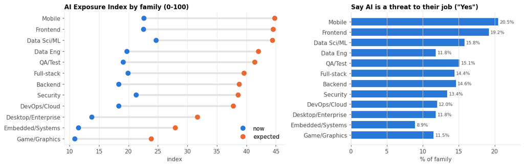

```python
print(f"rated at least {C.AI_MIN_TASKS_ANSWERED} of 13 tasks: {ai['ai_exposure_now'].notna().sum():,} "
      f"of {(ai['ai_tasks_rated'] > 0).sum():,} matrix respondents")
exp_fam = ai.groupby(FAM)[["ai_exposure_now", "ai_exposure_expected"]].mean().sort_values("ai_exposure_expected")
threat = ai.groupby(FAM)["AIThreat"].apply(lambda s: (s == "Yes").sum() / s.notna().sum() * 100)
fig, axes = plt.subplots(1, 2, figsize=(13, 4.2), gridspec_kw={"width_ratios": [1.3, 1]})
ax = axes[0]
y = np.arange(len(exp_fam))
ax.hlines(y, exp_fam["ai_exposure_now"], exp_fam["ai_exposure_expected"], color=viz.GRID, lw=3)
ax.plot(exp_fam["ai_exposure_now"], y, "o", color=viz.BLUE, ms=8, label="now")
ax.plot(exp_fam["ai_exposure_expected"], y, "o", color=viz.ORANGE, ms=8, label="expected")
ax.set_yticks(y, exp_fam.index)
ax.set(title="AI Exposure Index by family (0-100)", xlabel="index")
ax.legend(loc="lower right")
ax.grid(axis="y", visible=False)
viz.barh(axes[1], threat.loc[exp_fam.index[::-1]].index.tolist(), threat.loc[exp_fam.index[::-1]].round(1).tolist(),
         fmt="{:.1f}%")
axes[1].set(title='Say AI is a threat to their job ("Yes")', xlabel="% of family")
plt.tight_layout()
viz.save(fig, "02_ai_exposure_threat")
plt.show()
```

The app shows the AI outlook for each recommended **job role**, so the same measures are needed at job-role level, with the number of respondents behind each.

```python
by_job = ai.groupby(JOB).agg(
    n=("ai_exposure_now", "count"),
    exposure_now=("ai_exposure_now", "mean"),
    exposure_expected=("ai_exposure_expected", "mean"),
    threat_yes_pct=("AIThreat", lambda s: (s == "Yes").sum() / s.notna().sum() * 100),
).round(1).sort_values("exposure_expected", ascending=False)
by_job.insert(0, "family", by_job.index.map(C.ROLE_FAMILY))
by_job.index = by_job.index.map(C.JOB_ROLE_LABEL)
by_job
```

| JobRole | family | n | exposure_now | exposure_expected | threat_yes_pct |
| --- | --- | --- | --- | --- | --- |
| AI Application Developer | Data Sci/ML | 100 | 35.2 | 55.6 | 15.2 |
| UX / UI Designer | Frontend | 41 | 25.5 | 51.4 | 27.7 |
| AI / ML Engineer | Data Sci/ML | 308 | 31.5 | 50.6 | 17.9 |
| Mobile Developer | Mobile | 636 | 22.6 | 44.8 | 20.5 |
| Front-end Developer | Frontend | 970 | 22.4 | 44.2 | 18.8 |
| Data Engineer | Data Eng | 405 | 20.8 | 42.9 | 11.8 |
| Data / Business Analyst | Data Sci/ML | 164 | 18.9 | 42.7 | 22.3 |
| QA / Test Engineer | QA/Test | 173 | 19.1 | 41.4 | 15.1 |
| Data Scientist | Data Sci/ML | 304 | 22.7 | 41.4 | 13.8 |
| DevOps Engineer | DevOps/Cloud | 578 | 20.2 | 39.9 | 11.8 |
| Full-stack Developer | Full-stack | 6592 | 19.9 | 39.6 | 14.4 |
| Back-end Developer | Backend | 3358 | 18.3 | 38.8 | 14.6 |
| Cybersecurity Specialist | Security | 200 | 21.3 | 38.6 | 13.4 |
| Cloud Infrastructure Engineer | DevOps/Cloud | 218 | 18.1 | 38.4 | 13.9 |
| Database Administrator / Engineer | Data Eng | 78 | 14.2 | 37.3 | 11.7 |
| Applied Scientist | Data Sci/ML | 160 | 14.5 | 32.9 | 9.1 |
| System Administrator | DevOps/Cloud | 238 | 13.9 | 32.2 | 10.6 |
| Desktop / Enterprise Developer | Desktop/Enterprise | 1066 | 13.7 | 31.7 | 11.8 |
| Embedded Developer | Embedded/Systems | 708 | 11.5 | 27.9 | 8.9 |
| Game / Graphics Developer | Game/Graphics | 241 | 10.8 | 23.8 | 11.5 |

Every job role has at least about 40 respondents behind its AI figures in the training split, so job-role level AI summaries are usable; for the smallest roles the app should show the sample size and the family figure alongside.

## 7. Salary (supporting component)

Salary cohort: employed or self-employed professional developers with a reported salary, excluding the recommender test respondents.

```python
from skillpath.cleaning import drop_near_empty, drop_exact_duplicates, drop_straightliners, clean_experience
from skillpath.cohorts import build_salary_cohort

test_ids = set(pd.read_parquet(C.PROCESSED_DIR / "test.parquet")[C.ID_COL])
clean, _ = drop_near_empty(raw)
clean, _ = drop_exact_duplicates(clean)
clean, _ = drop_straightliners(clean)
clean, _ = clean_experience(clean)
sal, _ = build_salary_cohort(clean)
sal = sal[~sal[C.ID_COL].isin(test_ids)]
y = sal[C.SALARY_COL]
print(f"salary respondents: {len(sal):,}")
print(y.describe(percentiles=[0.01, 0.05, 0.5, 0.95, 0.99]).round(0).to_string())
print(f"skew raw: {y.skew():.1f}   skew log10: {np.log10(y).skew():.2f}")
```

```
salary respondents: 16,356
count       16356.0
mean       102919.0
std        331484.0
min             1.0
1%            106.0
5%           4413.0
50%         80000.0
95%        235038.0
99%        450000.0
max      33552715.0
skew raw: 72.8   skew log10: -2.70
```

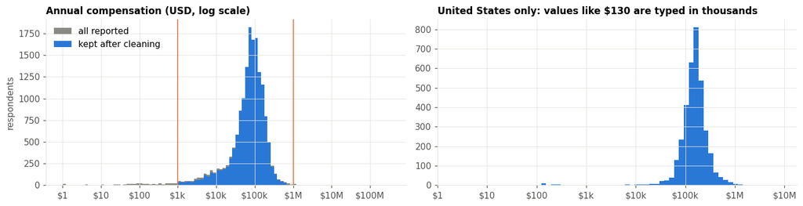

```
lowest US values: [ 10.  10.  30.  42.  64.  80.  80. 100. 125. 126. 130. 130.]
```

```python
ref = pd.read_parquet(C.REFERENCE_DIR / "salary_reference.parquet")
fig, axes = plt.subplots(1, 2, figsize=(13, 3.4))
bins = np.linspace(0, 8.5, 103)
axes[0].hist(np.log10(y), bins=bins, color=viz.MUTED, label="all reported")
axes[0].hist(ref["log10_salary"], bins=bins, color=viz.BLUE, label="kept after cleaning")
for b in (C.SALARY_MIN, C.SALARY_MAX):
    axes[0].axvline(np.log10(b), color=viz.ORANGE, lw=1)
axes[0].set_xticks(range(0, 9), ["$1", "$10", "$100", "$1k", "$10k", "$100k", "$1M", "$10M", "$100M"])
axes[0].set(title="Annual compensation (USD, log scale)", ylabel="respondents")
axes[0].legend()
axes[0].grid(axis="y")
us = sal[sal["Country"] == "United States of America"][C.SALARY_COL]
axes[1].hist(np.log10(us), bins=60, color=viz.BLUE)
axes[1].set_xticks(range(0, 8), ["$1", "$10", "$100", "$1k", "$10k", "$100k", "$1M", "$10M"])
axes[1].set(title="United States only: values like $130 are typed in thousands")
axes[1].grid(axis="y")
plt.tight_layout()
viz.save(fig, "02_salary")
plt.show()
print("lowest US values:", np.sort(us.values)[:12])
```

```python
rep = pd.read_csv(C.REPORTS_DIR / "salary_reference_attrition.csv")
rep
```

|  | step | records |
| --- | --- | --- |
| 0 | Developer by profession | 33542 |
| 1 | Employed or self-employed | 31212 |
| 2 | Reported annual compensation | 19443 |
| 3 | Exclude recommender test-set respondents | 16356 |
| 4 | Keep $1,000 to $1,000,000 | 15973 |
| 5 | Drop \|robust z\| > 3.5 within country/region | 15545 |

- Salary is extremely skewed (skew about 70 raw, far smaller in log10), so all salary work uses **log10 salary** and percentiles, never the mean.
- Two-stage outlier rule: (1) keep $1,000 to $1,000,000 per year; (2) within each country (or region if the country has fewer than 30 respondents) drop values whose robust z-score on log salary is above 3.5. Stage 2 catches values that are plausible globally but not for that country (US "$130" = 130k typed without zeros). Medians and MADs are learned on these reference rows only.

```python
ref["cell"] = ref["Country"].astype(str) + " | " + ref[FAM].astype(str) + " | " + ref["ExperienceBand"].astype(str)
cells = ref[ref[FAM].notna()].groupby("cell").size()
print(f"country x family x experience cells: {len(cells):,}; with >= {C.MIN_PEER_N} people: {(cells >= C.MIN_PEER_N).sum()} "
      f"(covering {cells[cells >= C.MIN_PEER_N].sum() / cells.sum():.1%} of respondents)")
reg = ref[ref[FAM].notna()].groupby(["Region", FAM, "ExperienceBand"]).size()
print(f"region x family x experience cells: {len(reg)}; with >= {C.MIN_PEER_N}: {(reg >= C.MIN_PEER_N).sum()} "
      f"(covering {reg[reg >= C.MIN_PEER_N].sum() / reg.sum():.1%})")
print("Sri Lanka respondents in the salary reference:", int((ref["Country"] == "Sri Lanka").sum()))
```

```
country x family x experience cells: 2,109; with >= 30 people: 82 (covering 42.5% of respondents)
region x family x experience cells: 592; with >= 30: 105 (covering 71.8%)
Sri Lanka respondents in the salary reference: 39
```

Country-level peer groups are too thin for most people, which confirms the proposal's **hierarchical fallback** (country, then region, then global) and the low-confidence warning for small groups such as Sri Lanka.

Because recommendations are job roles, the benchmark first tries the **job role** and falls back to the **family** when the job-role group is too small. For every salaried respondent in the recommender roles we find the most specific level whose group (always within the same experience band) has at least 30 people:

```python
r = ref[ref[JOB].notna()].copy()
r["level used"] = None
for role_col, geo in C.PEER_GROUP_LEVELS:
    keys = [role_col, "ExperienceBand"] + ([geo] if geo else [])
    size = r.groupby(keys)[C.SALARY_COL].transform("size")
    name = f"{role_col} x {geo or 'global'} x experience"
    r.loc[r["level used"].isna() & (size >= C.MIN_PEER_N), "level used"] = name
r["level used"] = r["level used"].fillna("no group with 30+ (show wide range only)")
cov = r["level used"].value_counts().rename("respondents").to_frame()
cov["share"] = (cov["respondents"] / len(r) * 100).round(1).astype(str) + "%"
cov
```

| level used | respondents | share |
| --- | --- | --- |
| JobRole x Country x experience | 5201 | 40.3% |
| JobRole x Region x experience | 3709 | 28.8% |
| JobRole x global x experience | 3160 | 24.5% |
| RoleFamily x global x experience | 256 | 2.0% |
| no group with 30+ (show wide range only) | 229 | 1.8% |
| RoleFamily x Country x experience | 210 | 1.6% |
| RoleFamily x Region x experience | 126 | 1.0% |

About 72% of people get a benchmark within their own country or region (69% at job-role level), about 26% need a global job-role or family group, and under 2% have no group of 30+ (the app then shows only a wide range with a warning). The app will always state which level was used and how many people are in it.

## 8. Leakage screen and redundancy

### 8.1 Is any candidate column suspiciously close to the target?

A column that almost determines the job role (V near 1) would suggest leakage, for example an answer that restates the job title. We screen every single-choice column and every technology option on the training split.

```python
single = []
for col in train.columns:
    if col in (C.ID_COL, JOB, FAM, "DevType", "split"):
        continue
    s = train[col]
    if pd.api.types.is_numeric_dtype(s) or s.astype(str).str.contains(";", regex=False).any():
        continue
    if 2 <= s.nunique() <= 60:
        single.append((col, round(cramers_v(s.fillna("Missing"), train[JOB]), 3)))
single = pd.DataFrame(single, columns=["column", "V with JobRole"]).sort_values("V with JobRole", ascending=False)

toks = []
for b, (have, want, _) in C.TECH_BLOCKS.items():
    for kind, col in (("have", have), ("want", want)):
        sets = train[col].map(parse_tokens)
        for t, n in sets.explode().value_counts().items():
            if n >= C.MIN_TOKEN_FREQUENCY * len(train):
                toks.append((f"{b} {kind}: {t}", round(cramers_v(sets.map(lambda s: t in s), train[JOB]), 3)))
toks = pd.DataFrame(toks, columns=["technology", "V with JobRole"]).sort_values("V with JobRole", ascending=False)
print("strongest single-choice columns:"); print(single.head(8).to_string(index=False))
print("\nstrongest technology options:"); print(toks.head(8).to_string(index=False))
print(f"\nmax V overall: {max(single['V with JobRole'].max(), toks['V with JobRole'].max()):.2f}")
```

```
strongest single-choice columns:
        column  V with JobRole
WebframeChoice           0.331
DatabaseChoice           0.312
    MainBranch           0.262
PlatformChoice           0.202
AIModelsChoice           0.126
       EdLevel           0.117
 DevEnvsChoice           0.114
      AISelect           0.105

strongest technology options:
               technology  V with JobRole
     Language have: Swift           0.425
Language have: JavaScript           0.423
  Language have: HTML/CSS           0.405
Language have: TypeScript           0.402
         Language have: C           0.374
       Language have: C++           0.365
     Webframe have: React           0.358
         Language have: R           0.343

max V overall: 0.42
```

No column comes close to determining the role (maximum V = 0.42, for Swift). The strongest single-choice columns are the technology gates (people who build no web apps are rarely web developers, V = 0.33), which is a legitimate signal, and the strongest technologies are exactly what we expect (Swift, JavaScript, HTML/CSS, C). MainBranch (V = 0.26) is a cohort/screening variable and is not a model input. **No hidden leakage was found.** The known leakage risks are handled by design:

| Risk | Handling |
| --- | --- |
| DevType, JobRole, RoleFamily as inputs | never in `model_input_columns()` (unit-tested) |
| CompTotal, Currency produce the salary | excluded everywhere |
| `...Admired` columns are derived from have + want | excluded |
| Test rows influencing preprocessing | split first; vocabularies, medians, scalers fitted on train only |
| Test rows in supporting tables | salary and persona tables exclude test IDs |
| CV folds influencing each other | whole preprocessing is inside the sklearn Pipeline, refitted per fold |

### 8.2 Redundancy between technologies

```python
M = H.loc[:, H.mean() >= 0.02]
corr = M.corr().abs().to_numpy(copy=True)
np.fill_diagonal(corr, 0)
iu = np.triu_indices_from(corr, 1)
pairs = pd.DataFrame({"a": M.columns[iu[0]], "b": M.columns[iu[1]], "abs r": corr[iu]}).sort_values("abs r", ascending=False)
print(pairs.head(8).round(3).to_string(index=False))
print(f"\npairs above 0.8: {(pairs['abs r'] > 0.8).sum()}")
```

```
                 a                       b  abs r
  Language: Elixir       Webframe: Phoenix  0.812
Database: Supabase      Platform: Supabase  0.778
    Language: Ruby Webframe: Ruby on Rails  0.778
      Language: C#  Webframe: ASP.NET Core  0.713
    Language: Rust         Platform: Cargo  0.708
      Language: C#         Platform: NuGet  0.687
   Platform: NuGet  Webframe: ASP.NET Core  0.671
      Language: C#  DevEnvs: Visual Studio  0.637

pairs above 0.8: 1
```

## 9. Findings that drive preprocessing

[output not shown]